# Week2

```python
import pandas as pd
import seaborn as sns
```

### Portfolio assignment 9

25 min: Perform a bivariate analysis on the columns with numerical data in the penguins dataset.

- Use corr() on the DataFrame to calculate all the correlations. Use the code example above to show the correlation table with colors.
- Look at the corrrelations. Do they match your expectations?
- Show a scatter plot for
  - The strongest positive correlation
  - The strongest negative correlation
  - The weakest correlation

```python
penguins = sns.load_dataset("penguins")
```

```python
penguins.head()
```

|  | species | island | bill_length_mm | bill_depth_mm | flipper_length_mm | body_mass_g | sex |
| --- | --- | --- | --- | --- | --- | --- | --- |
| 0 | Adelie | Torgersen | 39.1 | 18.7 | 181.0 | 3750.0 | Male |
| 1 | Adelie | Torgersen | 39.5 | 17.4 | 186.0 | 3800.0 | Female |
| 2 | Adelie | Torgersen | 40.3 | 18.0 | 195.0 | 3250.0 | Female |
| 3 | Adelie | Torgersen | NaN | NaN | NaN | NaN | NaN |
| 4 | Adelie | Torgersen | 36.7 | 19.3 | 193.0 | 3450.0 | Female |

```python
penguinsCorrelations = penguins.corr()
penguinsCorrelations.style.background_gradient(cmap='coolwarm', axis=None).set_precision(2)
```

|  | bill_length_mm | bill_depth_mm | flipper_length_mm | body_mass_g |
| --- | --- | --- | --- | --- |
| bill_length_mm | 1.00 | -0.24 | 0.66 | 0.60 |
| bill_depth_mm | -0.24 | 1.00 | -0.58 | -0.47 |
| flipper_length_mm | 0.66 | -0.58 | 1.00 | 0.87 |
| body_mass_g | 0.60 | -0.47 | 0.87 | 1.00 |

#### Conclusie

Naar mijn mening een logische verband tussen flipper_length en body_mass. Zelf had ik niet verwacht dat er zo weinig verband zou zitten tussen bill_depth en bill_length. Voor de rest zit het er nou mijn mening er zou uit zoals ik zelf een beetje zou verwachten.

#### The strongest postive correlation

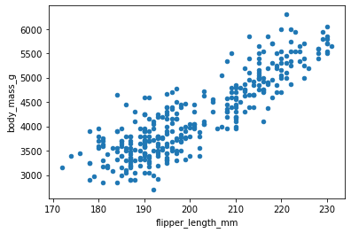

```python
penguins.plot(kind='scatter', x='flipper_length_mm', y='body_mass_g')
```

```python
penguins[['flipper_length_mm','body_mass_g']].corr()
```

|  | flipper_length_mm | body_mass_g |
| --- | --- | --- |
| flipper_length_mm | 1.000000 | 0.871202 |
| body_mass_g | 0.871202 | 1.000000 |

#### The strongest negative correlation

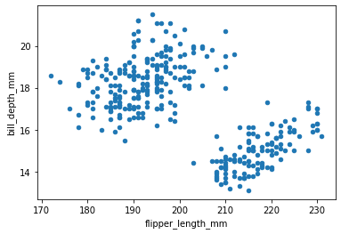

```python
penguins.plot(kind='scatter', x='flipper_length_mm', y='bill_depth_mm')
```

```python
penguins[['flipper_length_mm','bill_depth_mm']].corr()
```

|  | flipper_length_mm | bill_depth_mm |
| --- | --- | --- |
| flipper_length_mm | 1.000000 | -0.583851 |
| bill_depth_mm | -0.583851 | 1.000000 |

#### The weakest correlation

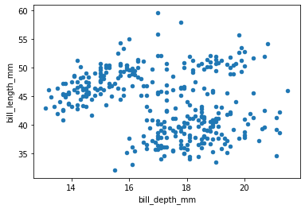

```python
penguins.plot(kind='scatter', x='bill_depth_mm', y='bill_length_mm')
```

```python
penguins[['bill_depth_mm','bill_length_mm']].corr()
```

|  | bill_depth_mm | bill_length_mm |
| --- | --- | --- |
| bill_depth_mm | 1.000000 | -0.235053 |
| bill_length_mm | -0.235053 | 1.000000 |

### Portfolio assignment 10

15 min: Perform a bivariate analysis (Pearson correlation and scatter plot) on at least 1 combination of 2 columns with numeric data in the dataset that you chose in portfolio assignment 4. Does the correlation and scatter plot match your expectations? Add your answer to your notebook. Commit the Notebook to your portfolio when you're finished.

```python
lecDataset = pd.read_csv('Datasets/lec_playerdata.csv', sep=',')
lecDataset.head()
```

|  | Unnamed: 0 | Player | Team | Pos | GP | W% | K | D | A | KDA | ... | CSD10 | CSPM | CS%P15 | DPM | DMG% | EGPM | Gold% | WPM | WCPM | Split |
| --- | --- | --- | --- | --- | --- | --- | --- | --- | --- | --- | --- | --- | --- | --- | --- | --- | --- | --- | --- | --- | --- |
| 0 | 0 | Abbedagge | Schalke 04 | Middle | 19.0 | 47.0 | 41.0 | 43.0 | 79.0 | 2.8 | ... | -3.3 | 9.0 | 26.6 | 417.0 | 24.6 | 257.9 | 22.5 | 0.51 | 0.19 | Spring Regular |
| 1 | 1 | Alphari | Origen | Top | 18.0 | 67.0 | 29.0 | 30.0 | 73.0 | 3.4 | ... | 1.7 | 8.0 | 22.4 | 354.0 | 21.8 | 243.5 | 20.9 | 0.54 | 0.15 | Spring Regular |
| 2 | 2 | Attila | Vitality | ADC | 18.0 | 56.0 | 48.0 | 30.0 | 77.0 | 4.2 | ... | -3.9 | 10.2 | 33.4 | 458.0 | 25.6 | 316.7 | 26.9 | 0.35 | 0.39 | Spring Regular |
| 3 | 3 | Broxah | Fnatic | Jungle | 18.0 | 61.0 | 49.0 | 27.0 | 93.0 | 5.3 | ... | -1.8 | 5.0 | 13.2 | 255.0 | 14.9 | 200.1 | 17.1 | 0.36 | 0.34 | Spring Regular |
| 4 | 4 | Bwipo | Fnatic | Top | 18.0 | 61.0 | 41.0 | 42.0 | 80.0 | 2.9 | ... | -10.0 | 7.6 | 23.6 | 444.0 | 25.5 | 239.7 | 20.4 | 0.48 | 0.16 | Spring Regular |

5 rows × 25 columns

```python
lecCorrelations = lecDataset.corr()
lecCorrelations.style.background_gradient(cmap='coolwarm', axis=None).set_precision(2)
```

|  | Unnamed: 0 | GP | W% | K | D | A | KDA | KP | DTH% | FB% | GD10 | XPD10 | CSD10 | CSPM | CS%P15 | DPM | DMG% | EGPM | Gold% | WPM | WCPM |
| --- | --- | --- | --- | --- | --- | --- | --- | --- | --- | --- | --- | --- | --- | --- | --- | --- | --- | --- | --- | --- | --- |
| Unnamed: 0 | 1.00 | -0.36 | -0.06 | -0.17 | -0.24 | -0.22 | 0.04 | -0.10 | -0.04 | -0.05 | -0.02 | -0.03 | -0.00 | -0.02 | 0.02 | 0.07 | 0.01 | 0.02 | 0.02 | -0.04 | 0.02 |
| GP | -0.36 | 1.00 | 0.14 | 0.72 | 0.87 | 0.84 | -0.09 | 0.17 | 0.06 | 0.11 | 0.16 | 0.14 | 0.10 | 0.06 | 0.00 | -0.11 | 0.01 | -0.02 | 0.01 | 0.01 | 0.18 |
| W% | -0.06 | 0.14 | 1.00 | 0.27 | 0.01 | 0.31 | 0.58 | 0.10 | -0.06 | 0.17 | 0.37 | 0.32 | 0.10 | 0.05 | -0.01 | 0.20 | -0.02 | 0.33 | 0.00 | -0.02 | 0.06 |
| K | -0.17 | 0.72 | 0.27 | 1.00 | 0.51 | 0.50 | 0.09 | 0.06 | -0.15 | 0.10 | 0.20 | 0.15 | 0.12 | 0.48 | 0.43 | 0.37 | 0.43 | 0.48 | 0.46 | -0.41 | 0.05 |
| D | -0.24 | 0.87 | 0.01 | 0.51 | 1.00 | 0.77 | -0.28 | 0.12 | 0.35 | 0.11 | 0.08 | 0.07 | 0.06 | -0.13 | -0.18 | -0.21 | -0.13 | -0.21 | -0.17 | 0.15 | 0.12 |
| A | -0.22 | 0.84 | 0.31 | 0.50 | 0.77 | 1.00 | 0.01 | 0.31 | 0.15 | 0.22 | 0.16 | 0.13 | 0.08 | -0.26 | -0.30 | -0.28 | -0.29 | -0.23 | -0.29 | 0.30 | 0.33 |
| KDA | 0.04 | -0.09 | 0.58 | 0.09 | -0.28 | 0.01 | 1.00 | 0.22 | -0.51 | 0.11 | 0.21 | 0.08 | -0.04 | 0.13 | 0.11 | 0.15 | 0.08 | 0.34 | 0.14 | -0.08 | 0.04 |
| KP | -0.10 | 0.17 | 0.10 | 0.06 | 0.12 | 0.31 | 0.22 | 1.00 | 0.03 | 0.29 | 0.09 | 0.02 | -0.01 | -0.29 | -0.28 | -0.34 | -0.30 | -0.22 | -0.22 | 0.26 | 0.45 |
| DTH% | -0.04 | 0.06 | -0.06 | -0.15 | 0.35 | 0.15 | -0.51 | 0.03 | 1.00 | -0.06 | -0.13 | -0.06 | -0.01 | -0.39 | -0.41 | -0.25 | -0.32 | -0.41 | -0.41 | 0.31 | -0.03 |
| FB% | -0.05 | 0.11 | 0.17 | 0.10 | 0.11 | 0.22 | 0.11 | 0.29 | -0.06 | 1.00 | 0.15 | 0.01 | -0.02 | -0.13 | -0.13 | -0.19 | -0.18 | -0.08 | -0.11 | 0.16 | 0.33 |
| GD10 | -0.02 | 0.16 | 0.37 | 0.20 | 0.08 | 0.16 | 0.21 | 0.09 | -0.13 | 0.15 | 1.00 | 0.55 | 0.61 | 0.12 | 0.07 | 0.21 | 0.09 | 0.24 | 0.10 | -0.01 | 0.07 |
| XPD10 | -0.03 | 0.14 | 0.32 | 0.15 | 0.07 | 0.13 | 0.08 | 0.02 | -0.06 | 0.01 | 0.55 | 1.00 | 0.68 | 0.15 | 0.09 | 0.11 | 0.04 | 0.17 | 0.08 | -0.10 | 0.02 |
| CSD10 | -0.00 | 0.10 | 0.10 | 0.12 | 0.06 | 0.08 | -0.04 | -0.01 | -0.01 | -0.02 | 0.61 | 0.68 | 1.00 | 0.16 | 0.12 | 0.10 | 0.06 | 0.13 | 0.08 | -0.06 | 0.03 |
| CSPM | -0.02 | 0.06 | 0.05 | 0.48 | -0.13 | -0.26 | 0.13 | -0.29 | -0.39 | -0.13 | 0.12 | 0.15 | 0.16 | 1.00 | 0.97 | 0.75 | 0.90 | 0.89 | 0.96 | -0.86 | -0.34 |
| CS%P15 | 0.02 | 0.00 | -0.01 | 0.43 | -0.18 | -0.30 | 0.11 | -0.28 | -0.41 | -0.13 | 0.07 | 0.09 | 0.12 | 0.97 | 1.00 | 0.76 | 0.89 | 0.88 | 0.97 | -0.82 | -0.35 |
| DPM | 0.07 | -0.11 | 0.20 | 0.37 | -0.21 | -0.28 | 0.15 | -0.34 | -0.25 | -0.19 | 0.21 | 0.11 | 0.10 | 0.75 | 0.76 | 1.00 | 0.85 | 0.87 | 0.78 | -0.73 | -0.44 |
| DMG% | 0.01 | 0.01 | -0.02 | 0.43 | -0.13 | -0.29 | 0.08 | -0.30 | -0.32 | -0.18 | 0.09 | 0.04 | 0.06 | 0.90 | 0.89 | 0.85 | 1.00 | 0.83 | 0.91 | -0.79 | -0.43 |
| EGPM | 0.02 | -0.02 | 0.33 | 0.48 | -0.21 | -0.23 | 0.34 | -0.22 | -0.41 | -0.08 | 0.24 | 0.17 | 0.13 | 0.89 | 0.88 | 0.87 | 0.83 | 1.00 | 0.92 | -0.79 | -0.32 |
| Gold% | 0.02 | 0.01 | 0.00 | 0.46 | -0.17 | -0.29 | 0.14 | -0.22 | -0.41 | -0.11 | 0.10 | 0.08 | 0.08 | 0.96 | 0.97 | 0.78 | 0.91 | 0.92 | 1.00 | -0.84 | -0.32 |
| WPM | -0.04 | 0.01 | -0.02 | -0.41 | 0.15 | 0.30 | -0.08 | 0.26 | 0.31 | 0.16 | -0.01 | -0.10 | -0.06 | -0.86 | -0.82 | -0.73 | -0.79 | -0.79 | -0.84 | 1.00 | 0.36 |
| WCPM | 0.02 | 0.18 | 0.06 | 0.05 | 0.12 | 0.33 | 0.04 | 0.45 | -0.03 | 0.33 | 0.07 | 0.02 | 0.03 | -0.34 | -0.35 | -0.44 | -0.43 | -0.32 | -0.32 | 0.36 | 1.00 |

#### GP (Games played) <=> D (Deaths)

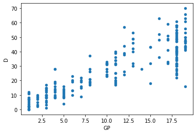

```python
lecDataset.plot(kind='scatter', x='GP', y='D')
```

```python
lecDataset[['GP','D']].corr()
```

|  | GP | D |
| --- | --- | --- |
| GP | 1.000000 | 0.868503 |
| D | 0.868503 | 1.000000 |

##### Conclusie

Hoe meer games je speelt lijkt het erop dat je ook meer D (deaths) pakt gedurende het toernooi. Wat ook een erg logisch verband lijkt.

#### GP (Games played) <=> A (Assists)

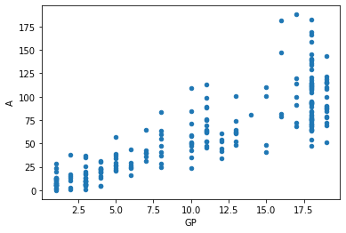

```python
lecDataset.plot(kind='scatter', x='GP', y='A')
```

```python
lecDataset[['GP', 'A']].corr()
```

|  | GP | A |
| --- | --- | --- |
| GP | 1.000000 | 0.840781 |
| A | 0.840781 | 1.000000 |

##### Conclusie

Hoe meer games je speelt lijkt het erop dat je ook meer A (assists) pakt gedurende het toernooi. Wat ook net zoals GP <=> D een erg logisch verband lijkt.

#### WPM (Average wards placed per minute) <=> CSPM (Average monsters + minions killed per minute)

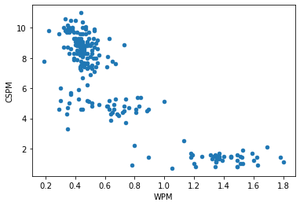

```python
lecDataset.plot(kind='scatter', x='WPM', y='CSPM')
```

```python
lecDataset[['WPM', 'CSPM']].corr()
```

|  | WPM | CSPM |
| --- | --- | --- |
| WPM | 1.000000 | -0.860972 |
| CSPM | -0.860972 | 1.000000 |

##### Conclusie

Der lijkt een verband te liggen tussen WPM en CSPM. Echter is het verband een beetje uit zijn context gehaald. Er zijn verschillende rollen in het spel en de ene rol vermoord heel weinig monsters en minions en plaatst veel meer wards. Echter kan je wel zeggen hoe meer wards je plaatst hoe minder monsters en minions je kan killen.

#### Gold% (Gold share: average share of team's total gold earned) <=> CSPM (Average monsters + minions killed per minute)

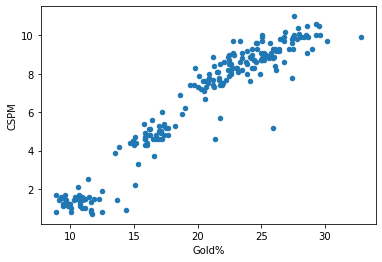

```python
lecDataset.plot(kind='scatter', x='Gold%', y='CSPM')
```

```python
lecDataset[['Gold%', 'CSPM']].corr()
```

|  | Gold% | CSPM |
| --- | --- | --- |
| Gold% | 1.000000 | 0.961681 |
| CSPM | 0.961681 | 1.000000 |

##### Conclusie

Der is een sterk verband tussen het aantal percentage gold dat je hebt verdiend voor je team en hoeveel monsters en minions je hebt vermoord. Je kan dit ook verklaren dat je geld krijgt per monster en minion en hoe meer je er vermoord hoe meer geld je krijgt.

#### Mijn verwachtingen

De verbanden die ik zag ik de data kwamen wel overeen met mijn verwachtingen. Vooral met de aantal games dat je dan meer deaths en assisten pakt. Ook de laatste twee onderdelen die ik heb onderzocht kwamen redelijk overeen met mijn verwachtingen voordat ik aan de opdracht begon.